# 第4回 利子と価格①：金利計算

## STEP 5 単利と差額の列

1. **単利**：B6 に  
   `=$B$1*(1+$B$2*A6)`
2. **差額**：D6 に `=C6-B6`  
   （同じ行を指すので `$` は不要）
3. **フィル**：B6 から D6 を  
   26 行目までドラッグ
4. **桁区切り**：B6:D26 を選び  
   ホームの「,」

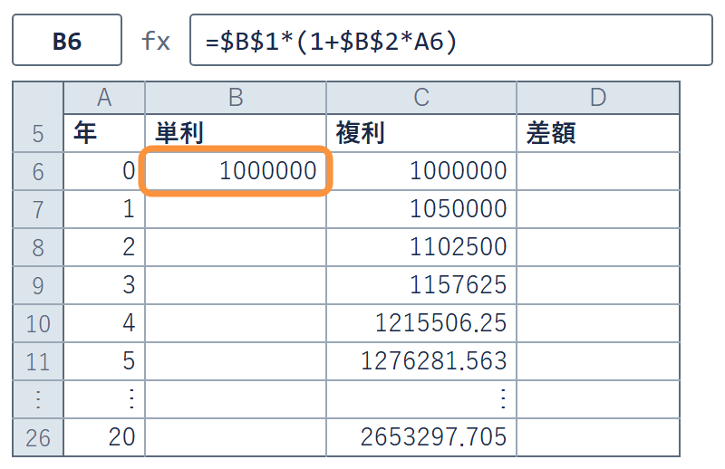

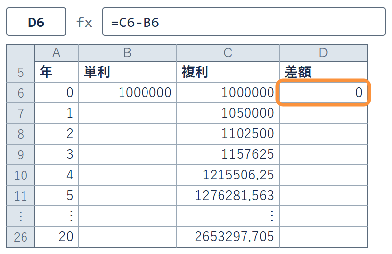

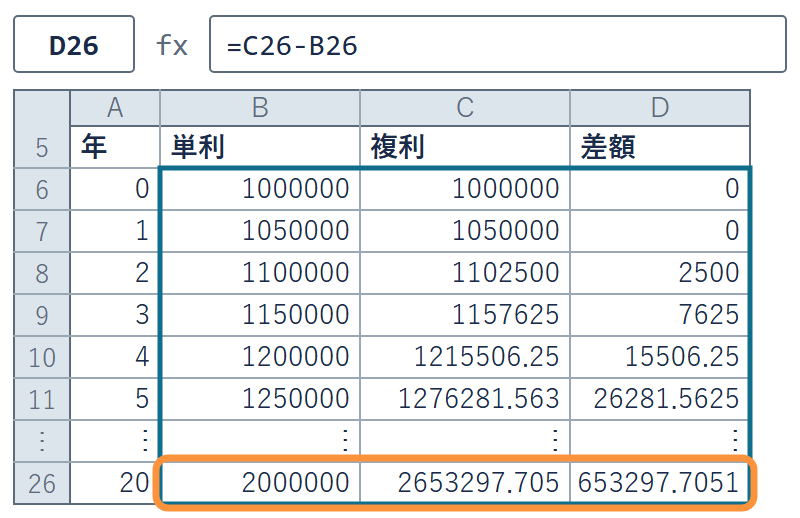

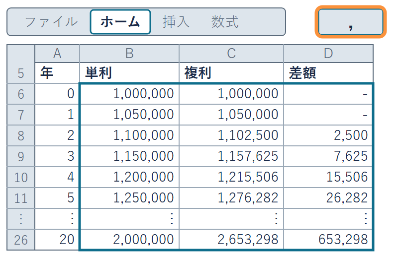

26 行目は 2,000,000 ／ 2,653,298 ／ 653,298

✋ 動画を止めて手順 1〜4 を進め、D26 が 653,298 なら再生に戻る

## 失敗例 `$` を付けすぎた式

年の A6 まで留める  
`=$B$1*(1+$B$2)^$A$6`  
C7 から C26 まで、全部 1,000,000

前提セルだけ留める  
`=$B$1*(1+$B$2)^A6`  
C26 は 2,653,298

- **なぜ起きるか**：「`$` を付ければ安全」と思いやすい
- **何が起きるか**：年がずっと A6 の 0 のまま。1.05 の 0 乗は 1
- **どう防ぐか**：前提セルか、行ごとに動く番地かを先に見る

## STEP 6 マーカー付き折れ線

1. **選ぶ**：見出しごと  
   A5:C26 をドラッグ
2. **挿入**：「挿入」→ 折れ線  
   → マーカー付き折れ線
3. **系列**：「データの選択」で  
   年の系列を削除
4. **横軸**：軸ラベルの「編集」で  
   A6:A26 を選ぶ

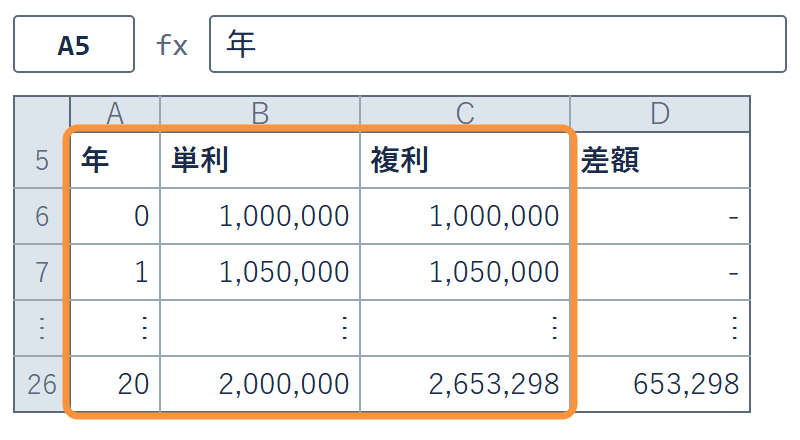

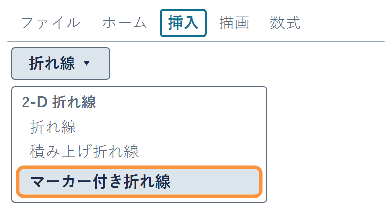

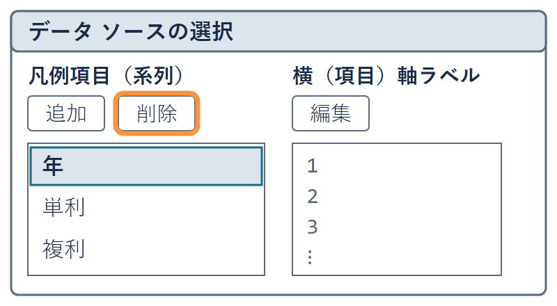

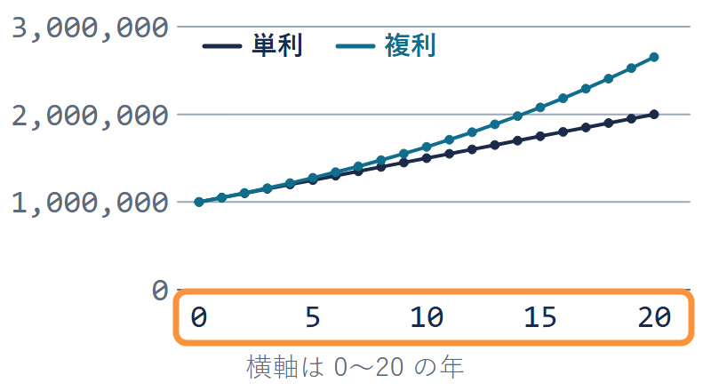

Mac は「グラフのデザイン」→「データの選択」

✋ 動画を止めて手順 1〜4 を進め、横軸が 0〜20 なら再生に戻る

## 後半に開く直線と曲線の差

[figure not shown]

差は 10 年後が D16 の 128,895 円  
20 年後が D26 の 653,298 円。後半で約 5 倍に開く

## 数で打った平均と番地で指す平均

出典：経済産業省「商業動態統計」スーパー販売額 2025 年（億円）  
置き場は lec4-exercise.xlsx の 29〜40 行。C 列の偏差は番地で新しく打つ

✗ 第3回のブック（平均を数で）  
C29 に `=B29-14002.08`  
偏差の合計は 0.04

◯ 平均の番地を `$` で留める  
C29 に `=B29-$B$41`  
偏差の合計は 0

- **0.04 の出どころ**：1 か月のずれ 0.0033… × 12 か月 ＝ 0.04
- **ずれの元**：平均 14002.08333… を、14002.08 と打った差
- **前に数で書いた理由**：B41 と書くと、  
  下へ引いたとき B42 や B43 へずれた

## STEP 7 販売額の偏差の式

1. **平均**：B41 に  
   `=AVERAGE(B29:B40)`
2. **偏差**：C29 に `=B29-$B$41`  
   C40 まで下へ（B29 だけ動く）
3. **合計**：C42 に `=SUM(C29:C40)`  
   （表示は小数 2 桁にしてある）

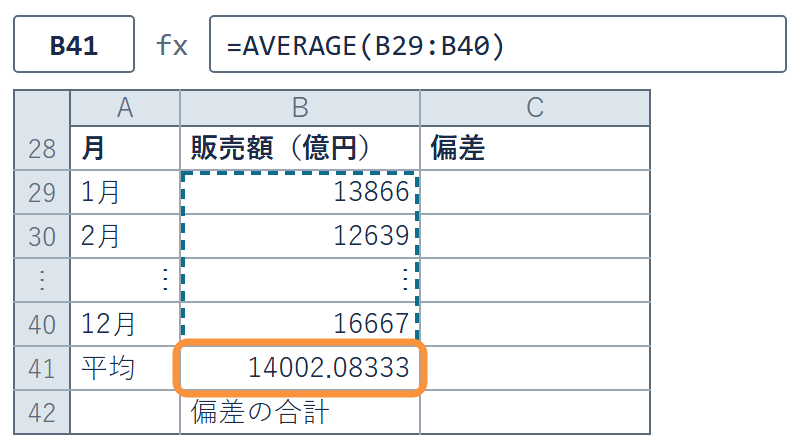

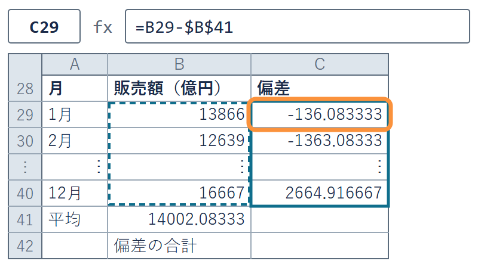

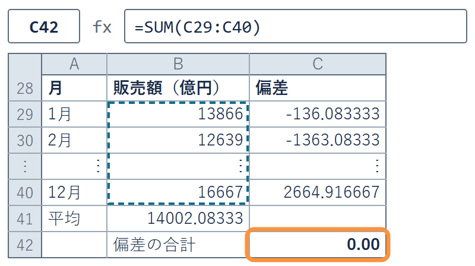

C29 は -136.083333 で C42 は 0.00 になる。平均からの差を全部足すと 0

✋ 動画を止めて手順 1〜3 を進め、C42 が 0.00 なら再生に戻る

## 演習 4-3 元金を 2 倍にした表

演習 4-3

B1 を 2000000 にすると、C26 はいくつになるか

1. **予想する**：元金を 2 倍にすると、C26 は何倍になるか
2. **変える所**：B1 を 2000000 に（表もグラフも作り直さない）
3. **書く場所**：C26 の値を K5 に打つ（円未満は四捨五入）
4. **戻す**：K5 に打ったら、B1 を 1000000 に戻す

✋ 動画を止めて 3 分。K5 に数を打ち、B1 を戻したら再生に戻る

## 演習 4-3 の答え

| B1 が 2000000 のとき | 値 | 打つ所 |
| --- | --- | --- |
| C26 複利の残高 | 5,306,595 | K5 |
| B26 単利の残高 | 4,000,000 | — |
| D26 差額 | 1,306,595 | — |

- **ちょうど 2 倍**：どの行の式も `$B$1` を指すので、  
  B1 を変えると 21 行が全部変わる
- **1 円のずれ**：C26 の中身は 2653297.7…。2 倍は 5306595.4… で、  
  表示の 2,653,298 の 2 倍とは 1 円ずれる
- **グラフも**：B1 を変えただけで描き直される

## Q&A

- **Q**：C29 が -136.083333 で、前の -136.08 と違う
  - **A**：前は平均を 14002.08 と打った。  
    いまは B41 の 14002.08333… をそのまま使う
- **Q**：B3 を 30 にしたのに、表が 30 年に伸びない
  - **A**：表は B3 を使っていない。年の列と式を 36 行目までフィルで伸ばす

## まとめ

- **コピーで番地は動く**：1.05 と 20 は、指す先が 1 行ずつ下へ動いた結果
- **番地に `$` を付けると留まる**：前提セルを `$B$1`・`$B$2`  
  で指せば、式 1 本で 21 行
- **付けすぎない**：行ごとに動いてほしい A6 には付けない
- **直線と曲線**：単利は直線、複利は後半ほど開く（20 年で差 653,298 円）
- **平均も番地で留める**：`=B29-$B$41` で偏差の合計は 0

次は、いまの金利で同じ表の 20 年後を確かめる

経済データ入門

第4回 — Topic04

利率・時間と複利の効き方

いまの金利で、20 年後はどこまで増えるか

## この回の道のり

1

利率と利息

演習 4-1

預金金利のカード

2

単利と複利

演習 4-2

20 年に伸ばす

3

絶対参照

演習 4-3

元金を 2 倍に

4

利率と時間

演習 4-4

カードローンで 5 年

いまここ — いまの金利で、20 年後はどこまで増えるか

## 「複利」シートで作る所

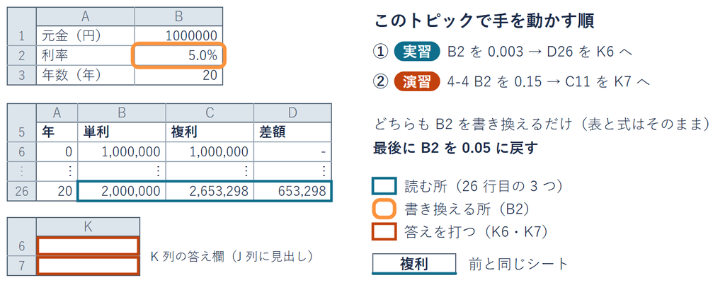

前と同じ「複利」シート。B2 を書き換えて、26 行目を読む

## 単利と複利の差の 4 マス

**サンプルデータ**：利率 5%（説明用の数）  
0.3% は 2026年9月時点の普通預金（日本銀行・H1）

[figure not shown]

3 マスは前に出した数。残るのは、0.3% で 20 年のマス

## 2 年の差 9 円の出どころ

2 年目の差 ＝ 1 年目の利息 × 利率 ＝ 元金 × 利率 × 利率

[figure not shown]

- **利率を 2 回掛ける**：利率が小さいと、利息に付く利息はもっと小さい
- **20 年では**：この小さな部品が、毎年積み重なっていく

## たしかめ：0.3% で 20 年の線

B2 を 0.3%（2026年9月時点の普通預金）にすると  
20 年の複利の線は、どうなるか

ア

**5% と同じように反る**

イ

**ほとんど直線**

ウ

**下がっていく**

1 つ決めてから先へ。答えは自分の折れ線で確かめる

## STEP 普通預金の利率への書き換え

1. **打つ**：B2 に 0.003  
   （H1 と同じ数・0.3% と見える）
2. **読む**：26 行目の B26・C26・D26  
   （折れ線も描き変わる）
3. **写す**：D26 の値を K6 に  
   （B2 は 0.003 のまま）

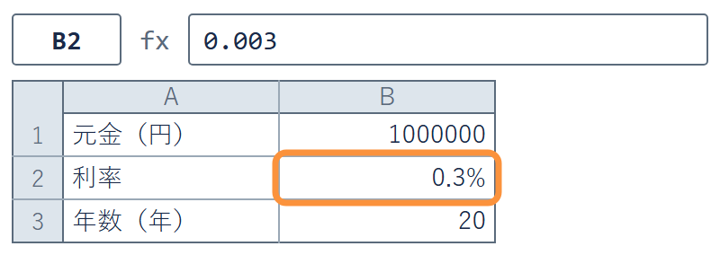

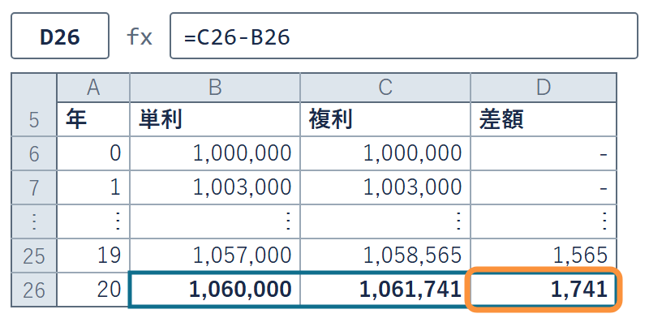

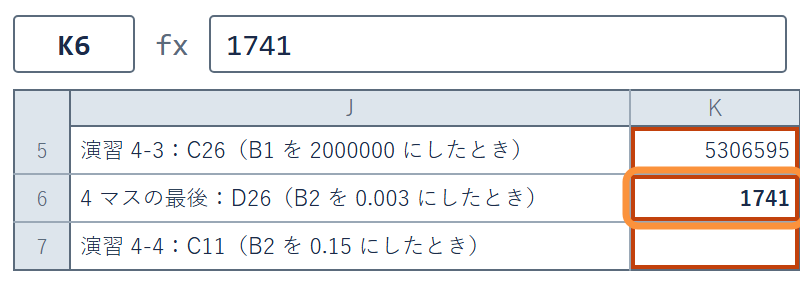

2026年9月時点の 0.3% で、26 行目は 1,060,000 ／ 1,061,741 ／ 1,741

✋ 動画を止めて手順 1〜3 を進め、K6 に 1741 と打ったら再生に戻る

## ほとんど直線になる 0.3% の複利

[figure not shown]

答えはイ。2026年9月時点の 0.3% では、  
20 年たっても差は 1,741 円

## 埋まった 4 マス

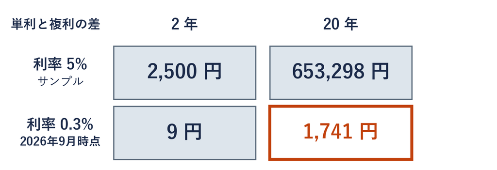

- **時間だけ長い**：0.3%（2026年9月時点）で 20 年なら、差は 1,741 円
- **利率だけ大きい**：5% でも 2 年なら、差は 2,500 円
- **両方そろう**：5% で 20 年なら 653,298 円。1,741 円はその約 375 分の 1

## 利率と時間で決まる複利の増え方

決め

**複利の増え方は、利率と時間の両方で決まる**  
どちらかが小さいと、単利との差は開かない

- **式で見ると**：C26 の `=$B$1*(1+$B$2)^A26` の B2 が利率、A26 が年数
- **利率**：1 に利率を足した数を毎年掛ける  
  （5% なら 1.05、2026年9月時点の 0.3% なら 1.003）
- **時間**：掛ける回数（20 年なら 20 回）

表示の金利は税を引く前。受け取る利息からは税金が引かれる

## 失敗例 B2 に 0.3 と打った前提セル

0.3% のつもりで 0.3  
B2 の見え方は 30.0%  
C26 は 190,049,638

0.3% は 0.003  
B2 の見え方は 0.3%  
C26 は 1,061,741

- **なぜ起きるか**：「0.3%（2026年9月時点の普通預金）」  
  の 0.3 だけを打ちたくなる
- **何が起きるか**：利率が 100 倍の 30% になり、C26 は元金の約 190 倍
- **どう防ぐか**：打ったあと、B2 の見え方が 0.3% かを確かめる

## 借りる側の金利 15%

出典：利息制限法 第1条  
（元本 100 万円以上の上限・法律なので毎年は変わらない）  
置き場は lec4-exercise.xlsx の H2（0.15）

- **同じ式**：借りたお金も、返さずにいると利息に利息が付く
- **向きが逆**：預ける側で増える差は、借りる側では払う額
- **桁**：上限 15% は、2026年9月時点の普通預金 0.3% の 50 倍

B2 を 15% にすると、5 年で残高はどこまで増えるか

## 演習 4-4 カードローンで 5 年

演習 4-4

B2 を 0.15 にすると、5 年後（C11）はいくらか

1. **予想する**：100 万円を上限 15% で借り、5 年返さないといくらになるか
2. **変える所**：B2 を 0.15 に（H2 と同じ数・15.0% と見える）
3. **書く場所**：C11 の値を K7 に打つ（円未満は四捨五入）
4. **戻す**：K7 に打ったら、B2 を 0.05 に戻す

✋ 動画を止めて 3 分。K7 に数を打ち、B2 を戻したら再生に戻る

## 演習 4-4 の答え

| B2 が 0.15（上限 15%）のとき | 値 | 打つ所 |
| --- | --- | --- |
| C11 複利の残高（5 年後） | 2,011,357 | K7 |
| B11 単利の残高 | 1,750,000 | — |
| D11 差額 | 261,357 | — |

- **利息だけで 1,011,357 円**：5 年で、借りた 100 万円より多くなる
- **前提**：返済なし・年 1 回の複利・利率は一定（比べるための計算）
- **預ける側では**：0.3%（2026年9月時点）で 20 年でも利息は 61,741 円

## Q&A

- **Q**：K6 には 1741 と 1741.18 のどちらを打つか
  - **A**：円未満を四捨五入した 1741 を打つ  
    D26 の中身は 1741.176…（桁区切りの表示で隠れている）
- **Q**：B2 に 0.3%（2026年9月時点）と、% まで打ってもよいか
  - **A**：よい。0.003 と打ったのと同じ数が入る
- **Q**：B2 を戻し忘れて、表もグラフも変わったまま
  - **A**：B2 を 0.05 に戻せば、表もグラフも 5% に戻る

## まとめ

- **利率と利息**：利息 ＝ 元金 × 利率。金利は「いつの、誰の」数かを書く
- **単利と複利**：単利は同じ額を足し、複利は利息にも利息が付く
- **前提セル**：元金・利率・年数はセルに置き、式は番地で指す
- **絶対参照 `$`**：コピーしても動かしたくない番地を留める
- **利率と時間**：2026年9月時点の 0.3% では、20 年たっても差は 1,741 円

複利の増え方は、利率と時間の両方で決まる